# STA-6543: Assignment 6

Austin Thrash - FFK221

2024-03-21

## ISLR Chapter 7

### Question 6

**In this exercise, you will further analyze the Wage data set considered throughout this chapter.**

```r
head(Wage)
```

```
##        year age           maritl     race       education             region
## 231655 2006  18 1. Never Married 1. White    1. < HS Grad 2. Middle Atlantic
## 86582  2004  24 1. Never Married 1. White 4. College Grad 2. Middle Atlantic
## 161300 2003  45       2. Married 1. White 3. Some College 2. Middle Atlantic
## 155159 2003  43       2. Married 3. Asian 4. College Grad 2. Middle Atlantic
## 11443  2005  50      4. Divorced 1. White      2. HS Grad 2. Middle Atlantic
## 376662 2008  54       2. Married 1. White 4. College Grad 2. Middle Atlantic
##              jobclass         health health_ins  logwage      wage
## 231655  1. Industrial      1. <=Good      2. No 4.318063  75.04315
## 86582  2. Information 2. >=Very Good      2. No 4.255273  70.47602
## 161300  1. Industrial      1. <=Good     1. Yes 4.875061 130.98218
## 155159 2. Information 2. >=Very Good     1. Yes 5.041393 154.68529
## 11443  2. Information      1. <=Good     1. Yes 4.318063  75.04315
## 376662 2. Information 2. >=Very Good     1. Yes 4.845098 127.11574
```

#### 6.(a) *Age* to predict *Wage:* Polynomial Regression

**Perform polynomial regression to predict wage using age. Use cross-validation to select the optimal degree d for the polynomial. What degree was chosen, and how does this compare to the results of hypothesis testing using ANOVA? Make a plot of the resulting polynomial fit to the data.**

```r
# Hypothesis Testing Using ANOVA
ploymodel1 <- lm(wage ~ poly(age, 1), data=Wage)
ploymodel2 <- lm(wage ~ poly(age, 2), data=Wage)
ploymodel3 <- lm(wage ~ poly(age, 3), data=Wage)
ploymodel4 <- lm(wage ~ poly(age, 4), data=Wage)
ploymodel5 <- lm(wage ~ poly(age, 5), data=Wage)

anova_results <- anova(ploymodel1, ploymodel2, ploymodel3, ploymodel4, ploymodel5)
print(anova_results)
```

```
## Analysis of Variance Table
##
## Model 1: wage ~ poly(age, 1)
## Model 2: wage ~ poly(age, 2)
## Model 3: wage ~ poly(age, 3)
## Model 4: wage ~ poly(age, 4)
## Model 5: wage ~ poly(age, 5)
##   Res.Df     RSS Df Sum of Sq        F    Pr(>F)
## 1   2998 5022216
## 2   2997 4793430  1    228786 143.5931 < 2.2e-16 ***
## 3   2996 4777674  1     15756   9.8888  0.001679 **
## 4   2995 4771604  1      6070   3.8098  0.051046 .
## 5   2994 4770322  1      1283   0.8050  0.369682
## ---
## Signif. codes:  0 '***' 0.001 '**' 0.01 '*' 0.05 '.' 0.1 ' ' 1
```

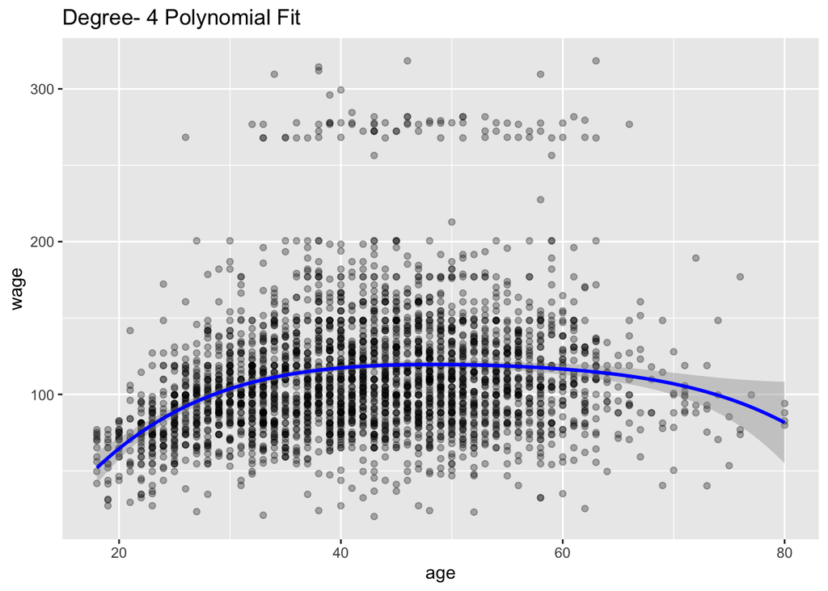

```r
# Polynomial Regression Using Cross-Validation
set.seed(4)
cv.error.10 <- rep(0, 10)
for (i in 1:10) {
  glm.fit <- glm(wage ~ poly(age, i), data = Wage)
  cv.error.10[i] <- cv.glm(Wage, glm.fit, K = 10)$delta[1]
}

# Getting model number with lowest MSE
optimal.degree <- which.min(cv.error.10)

# Create Formula
formula_str <- sprintf("y ~ poly(x, %d, raw = TRUE)", optimal.degree)

# Convert to formula object
formula_obj <- as.formula(formula_str)

# Plotting
ggplot(Wage, aes(x = age, y = wage)) +
  geom_point(alpha = 0.3) +
  geom_smooth(method = "lm", formula = formula_obj, color = "blue") +
  labs(title = paste("Degree-", optimal.degree, "Polynomial Fit"))
```

When performing Polynomial Regression using cross-validation (k-fold validation), the results suggest using a degree of 4 and it seems to be a pretty good fit. However when using hypothesis testing using ANOVA, the optimal degree is 3, as going any higher than that does not grant significant improvement to the model and will add further complexity.

#### 6.(b) *Age* to predict *Wage*: Step Function

**Fit a step function to predict wage using age, and perform cross-validation to choose the optimal number of cuts. Make a plot of the fit obtained.**

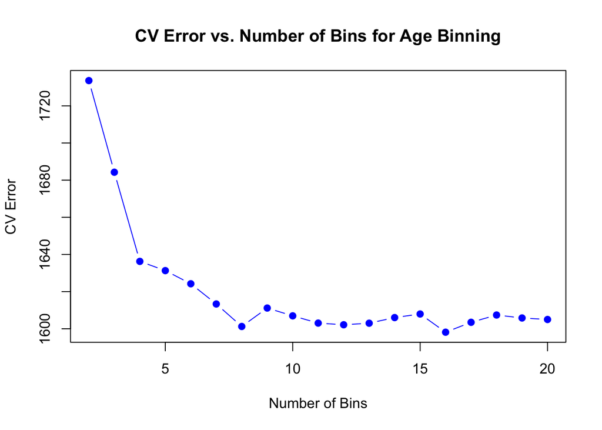

```r
set.seed(4)
cuts <- numeric(19)
for (i in 2:20) {
  Wage$age_cut <- cut(Wage$age, i, include.lowest = TRUE)

  lm.fit <- glm(wage ~ age_cut, data = Wage)

  cuts[i - 1] <- cv.glm(Wage, lm.fit, K = 10)$delta[1]
}

bins <- 2:20

plot(bins, cuts, type = "b", pch = 19, col = "blue", xlab = "Number of Bins", ylab = "CV Error", main = "CV Error vs. Number of Bins for Age Binning")
```

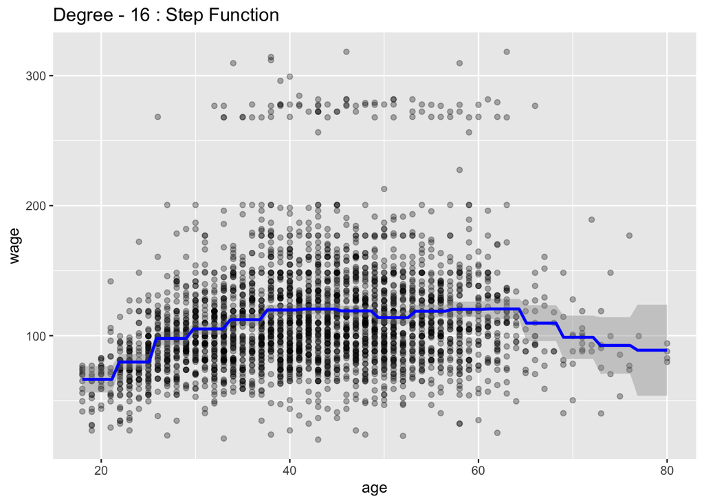

```r
# Getting model number with lowest MSE
optimal.cut <- which.min(cuts) + 1

# Create Formula
formula_str <- sprintf("y ~ cut(x, %d, raw = TRUE)", optimal.cut)

# Convert to formula object
formula_obj <- as.formula(formula_str)

# Plotting
ggplot(Wage, aes(x = age, y = wage)) +
  geom_point(alpha = 0.3) +
  geom_smooth(method = "lm", formula = formula_obj, color = "blue") +
  labs(title = paste("Degree -", optimal.cut, ": Step Function"))
```

When using the step function to predict Wage using Age, the results suggest using a step function with 16 intervals. However I would most likely use an interval of 7 or 8 as the “1 Standard Deviation” rule applies and they would make the model less complex.

### Question 10

**This question relates to the College data set.**

```r
head(College)
```

```
##                              Private Apps Accept Enroll Top10perc Top25perc
## Abilene Christian University     Yes 1660   1232    721        23        52
## Adelphi University               Yes 2186   1924    512        16        29
## Adrian College                   Yes 1428   1097    336        22        50
## Agnes Scott College              Yes  417    349    137        60        89
## Alaska Pacific University        Yes  193    146     55        16        44
## Albertson College                Yes  587    479    158        38        62
##                              F.Undergrad P.Undergrad Outstate Room.Board Books
## Abilene Christian University        2885         537     7440       3300   450
## Adelphi University                  2683        1227    12280       6450   750
## Adrian College                      1036          99    11250       3750   400
## Agnes Scott College                  510          63    12960       5450   450
## Alaska Pacific University            249         869     7560       4120   800
## Albertson College                    678          41    13500       3335   500
##                              Personal PhD Terminal S.F.Ratio perc.alumni Expend
## Abilene Christian University     2200  70       78      18.1          12   7041
## Adelphi University               1500  29       30      12.2          16  10527
## Adrian College                   1165  53       66      12.9          30   8735
## Agnes Scott College               875  92       97       7.7          37  19016
## Alaska Pacific University        1500  76       72      11.9           2  10922
## Albertson College                 675  67       73       9.4          11   9727
##                              Grad.Rate
## Abilene Christian University        60
## Adelphi University                  56
## Adrian College                      54
## Agnes Scott College                 59
## Alaska Pacific University           15
## Albertson College                   55
```

#### 10.(a)

**Split the data into a training set and a test set. Using out-of-state tuition as the response and the other variables as the predictors, perform forward stepwise selection on the training set in order to identify a satisfactory model that uses just a subset of the predictors.**

```r
# Performing 70/30 train test split
set.seed(4)
train_index <- sample(1:nrow(College), round(nrow(College) * 0.7))

train <- College[train_index, ]
test <- College[-train_index, ]

nv_max <- ncol(College) - 2

fwd <- regsubsets(Outstate ~ ., data = train, method = "forward", nvmax = nv_max)
summary1 <- summary(fwd)
summary1
```

```
## Subset selection object
## Call: regsubsets.formula(Outstate ~ ., data = train, method = "forward",
##     nvmax = nv_max)
## 17 Variables  (and intercept)
##             Forced in Forced out
## PrivateYes      FALSE      FALSE
## Apps            FALSE      FALSE
## Accept          FALSE      FALSE
## Enroll          FALSE      FALSE
## Top10perc       FALSE      FALSE
## Top25perc       FALSE      FALSE
## F.Undergrad     FALSE      FALSE
## P.Undergrad     FALSE      FALSE
## Room.Board      FALSE      FALSE
## Books           FALSE      FALSE
## Personal        FALSE      FALSE
## PhD             FALSE      FALSE
## Terminal        FALSE      FALSE
## S.F.Ratio       FALSE      FALSE
## perc.alumni     FALSE      FALSE
## Expend          FALSE      FALSE
## Grad.Rate       FALSE      FALSE
## 1 subsets of each size up to 16
## Selection Algorithm: forward
##           PrivateYes Apps Accept Enroll Top10perc Top25perc F.Undergrad
## 1  ( 1 )  " "        " "  " "    " "    " "       " "       " "
## 2  ( 1 )  "*"        " "  " "    " "    " "       " "       " "
## 3  ( 1 )  "*"        " "  " "    " "    " "       " "       " "
## 4  ( 1 )  "*"        " "  " "    " "    " "       " "       " "
## 5  ( 1 )  "*"        " "  " "    " "    " "       " "       " "
## 6  ( 1 )  "*"        " "  " "    " "    " "       " "       " "
## 7  ( 1 )  "*"        " "  " "    " "    " "       " "       " "
## 8  ( 1 )  "*"        " "  "*"    " "    " "       " "       " "
## 9  ( 1 )  "*"        " "  "*"    "*"    " "       " "       " "
## 10  ( 1 ) "*"        "*"  "*"    "*"    " "       " "       " "
## 11  ( 1 ) "*"        "*"  "*"    "*"    "*"       " "       " "
## 12  ( 1 ) "*"        "*"  "*"    "*"    "*"       " "       " "
## 13  ( 1 ) "*"        "*"  "*"    "*"    "*"       " "       " "
## 14  ( 1 ) "*"        "*"  "*"    "*"    "*"       " "       " "
## 15  ( 1 ) "*"        "*"  "*"    "*"    "*"       " "       "*"
```

[output cut: 20 more lines]

```
## 2  ( 1 )  " "         "*"    " "
## 3  ( 1 )  " "         "*"    " "
## 4  ( 1 )  "*"         "*"    " "
## 5  ( 1 )  "*"         "*"    "*"
## 6  ( 1 )  "*"         "*"    "*"
## 7  ( 1 )  "*"         "*"    "*"
## 8  ( 1 )  "*"         "*"    "*"
## 9  ( 1 )  "*"         "*"    "*"
## 10  ( 1 ) "*"         "*"    "*"
## 11  ( 1 ) "*"         "*"    "*"
## 12  ( 1 ) "*"         "*"    "*"
## 13  ( 1 ) "*"         "*"    "*"
## 14  ( 1 ) "*"         "*"    "*"
## 15  ( 1 ) "*"         "*"    "*"
## 16  ( 1 ) "*"         "*"    "*"
```

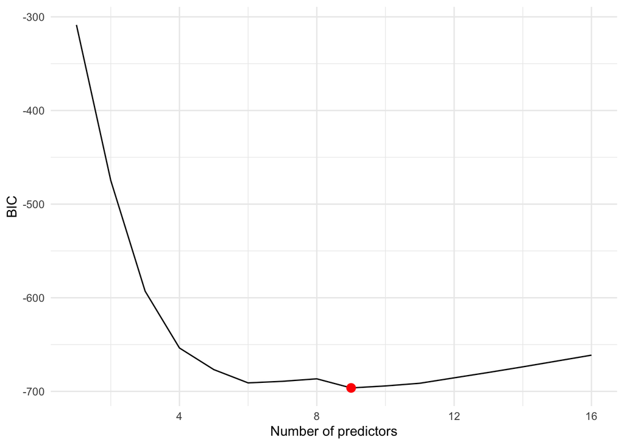

```r
ggplot() +
  geom_path(aes(x = seq_along(summary1$bic), y = summary1$bic)) +
  geom_point(aes(x = which.min(summary1$bic), y = min(summary1$bic)), size = 3, colour = "red") +
  xlab("Number of predictors") +
  ylab("BIC") +
  theme_minimal()
```

When performing forward stepwise selection and using the out-of-state tutition as the response variable, the results suggest using 9 predictors which are:

*Private, Accept, Enroll, Room.Board, Personal, Terminal, perc.alumni, Expend, and Grad.Rate*

However if I were picking the number of predictors I would most likely chose to use 5 as it has a BIC value closer the BIC value when using 9 predictors. This would also reduce the complexity of the model and might provide more accurate results.

#### 10.(b)

**Fit a GAM on the training data, using out-of-state tuition as the response and the features selected in the previous step as the predictors. Plot the results, and explain your findings.**

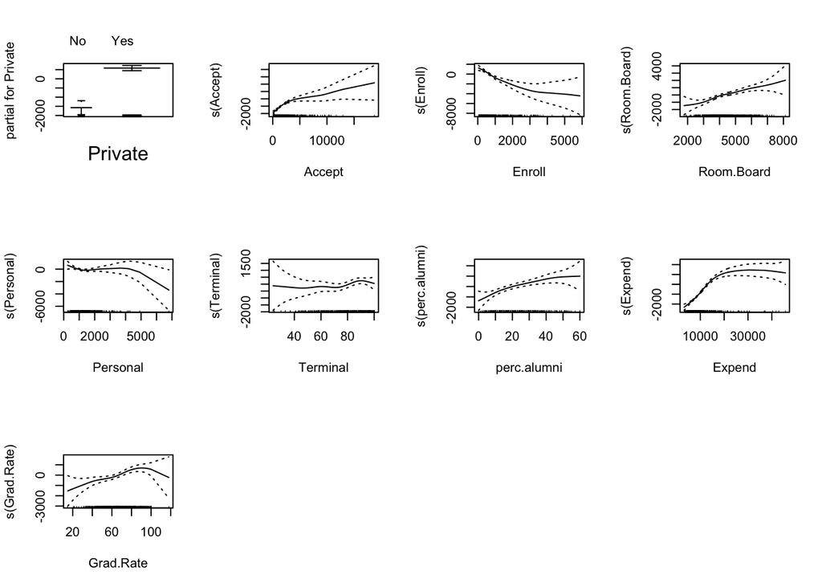

```r
fits <- gam(Outstate ~ Private + s(Accept) + s(Enroll) + s(Room.Board) + s(Personal) + s(Terminal) + s(perc.alumni) + s(Expend) + s(Grad.Rate), data = train)
par(mfrow = c(3,4))
plot(fits, se = TRUE)
```

From the results, we can see that ‘*Private*’, ‘*Accept*’, ‘*Room.Board*’, ‘*perc.alumni*’, ‘*Expend*’, and ‘*Grad.Rate*’ all seem to exhibit a positive relationship with the response variable; For each increase in these variables we can expect to see an increase in the response on average. While ‘*Enroll*’ and ‘*Personal*’ have a negative relationship with the response; On average we expect to see a decrease in the response for each increase of these variables.

#### 10.(c)

**Evaluate the model obtained on the test set, and explain the results obtained.**

```r
preds_nonlinear <- predict(fits, newdata = test)
mse_nonlinear <- mean((preds_nonlinear - test$Outstate)^2)

fits_lm <- lm(Outstate ~ Private + Accept + Enroll + Room.Board + Personal + Terminal + perc.alumni + Expend + Grad.Rate, data = train)
preds_linear <- predict(fits_lm, newdata = test)
mse_linear <- mean((preds_linear - test$Outstate)^2)

paste("Linear RMSE:", sqrt(mse_linear))
```

```
## [1] "Linear RMSE: 2015.98979665636"
```

```r
paste("Non-linear RMSE:", sqrt(mse_nonlinear))
```

```
## [1] "Non-linear RMSE: 1801.15924523687"
```

We can evaluate the model by looking at the “R Mean Squared Error” (RMSE) and comparing it to a normal linear model RMSE using the same predictors. From the results we can see that the non-linear model out performed the linear model by a difference of about 214. However if using less predictors, one could possibly obtain better results.

#### 10.(d)

**For which variables, if any, is there evidence of a non-linear relationship with the response?**

```r
summary(fits)
```

```
##
## Call: gam(formula = Outstate ~ Private + s(Accept) + s(Enroll) + s(Room.Board) +
##     s(Personal) + s(Terminal) + s(perc.alumni) + s(Expend) +
##     s(Grad.Rate), data = train)
## Deviance Residuals:
##      Min       1Q   Median       3Q      Max
## -6562.89 -1105.46    55.91  1204.22  7257.87
##
## (Dispersion Parameter for gaussian family taken to be 3227875)
##
##     Null Deviance: 8687534607 on 543 degrees of freedom
## Residual Deviance: 1646217794 on 510.0004 degrees of freedom
## AIC: 9731.806
##
## Number of Local Scoring Iterations: NA
##
## Anova for Parametric Effects
##                 Df     Sum Sq    Mean Sq F value    Pr(>F)
## Private          1 2356834941 2356834941 730.151 < 2.2e-16 ***
## s(Accept)        1  612448391  612448391 189.737 < 2.2e-16 ***
## s(Enroll)        1  133668721  133668721  41.411 2.847e-10 ***
## s(Room.Board)    1 1042887706 1042887706 323.088 < 2.2e-16 ***
## s(Personal)      1   53770186   53770186  16.658 5.194e-05 ***
## s(Terminal)      1  336364664  336364664 104.206 < 2.2e-16 ***
## s(perc.alumni)   1  376312664  376312664 116.582 < 2.2e-16 ***
## s(Expend)        1  830223945  830223945 257.204 < 2.2e-16 ***
## s(Grad.Rate)     1   66909075   66909075  20.729 6.625e-06 ***
## Residuals      510 1646217794    3227875
## ---
## Signif. codes:  0 '***' 0.001 '**' 0.01 '*' 0.05 '.' 0.1 ' ' 1
##
## Anova for Nonparametric Effects
##                Npar Df Npar F     Pr(F)
## (Intercept)
## Private
## s(Accept)            3 14.369 5.313e-09 ***
## s(Enroll)            3  5.854 0.0006175 ***
## s(Room.Board)        3  1.282 0.2797653
## s(Personal)          3  3.504 0.0153515 *
## s(Terminal)          3  1.961 0.1188499
## s(perc.alumni)       3  0.917 0.4323377
## s(Expend)            3 32.193 < 2.2e-16 ***
## s(Grad.Rate)         3  1.997 0.1134792
## ---
## Signif. codes:  0 '***' 0.001 '**' 0.01 '*' 0.05 '.' 0.1 ' ' 1
```

To answer this question we can look at the “Anova for Nonparametric Effects” section. The only variables that exhibit a non-linear relationship with the response is ‘*Accept*’, ‘*Enroll*’, ‘*Personal*’, and ‘*Expend*’ with p-values of 5.313e-09, 0.0006175, 0.0153515, and <2.2e-16 respectively.